# LINEAR REGRESSION FROM SCRATCH

Andra Tomi (Gr 405)

Adrian Apostol (Gr 405)

29 November 2020

## **1. Linear Regression**

**Univariate linear regression/simple linear regression** is a linear regression with one variable x. It is an example of **supervised learning** where the output values are known in the training data. In simple linear regression, for each input is predicted a single output.

### a) Hypothesis Function

**Multivariate linear regression/multiple linear regression** is a linear regression with many variables x.

**The hypothesis function:**

$h_w(x) = w_0 + w_1x_1 + ... +w_nx_n + \epsilon = \sum\limits_{j=0}^{n}(w_jx_j) + \epsilon$

**Example of simple linear regression** as ordinary least squares (Fig.1.):

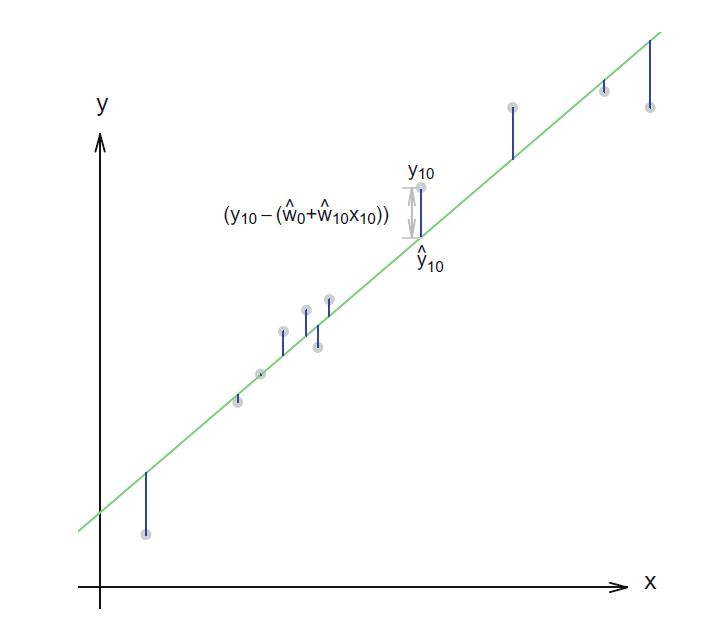

Fig.1  
- green line = regression line  
- blue line = error (the difference between the actual values and the predicted values)

### b) Cost Function

For each $w_0,w_1...w_n$ there is a regression line. It should be found a single regression line which minimizes the cost function. The one in this case is the **residual sum of squares (RSS)**.  
**The cost function for a generalized regression equation:**

$RSS(w) = \sum\limits_{i=1}^{m} \left(y^{(i)} - (\sum\limits_{j=1}^{n}w_{j}x_{j}^{(i)})\right)^{2} = \frac{1}{2m}\sum\limits_{i=1}^{m} (y^{(i)} - h_w(x^{(i)})^2 = (y - H_w)^T(y-H_w)$ **(1.1)**

$\frac{1}{2}$ - for convenience; useful when calculating the first derivative of the function  
x(i), y(i) - the i-th row values of x and y in the data set  
m - number of training example  
n - number of input variables

## **2. Linear Regression as Ordinary Least Squares**

The fit (in Fig.1) is calculated by minimizing the sum of squared errors.

**Error for observation at step i:**

if $\hat{y}_i=\hat{w}_0+\hat{w}_1x_i$ => $e_i=y_i-\hat{y}_i$

**Error for all observations:**

$RSS = e_1^2+e_2^2+...+e_m^2 = (y_1-\hat{w}_0-\hat{w}_1x_1)^2+...+(y_m-\hat{w}_0-\hat{w}_1x_m)^2$  
$RSS = \sum\limits_{i=1}^{m}(y_i-\hat{w}_0-\hat{w}_1x_i)^2$

Differentiate with respect to $w_0$ and $w_1$ to **minimize RSS**:  
$\frac{\partial RSS}{\partial w_0} = \frac{\partial }{\partial w_0}\sum\limits_{i=1}^{m}(y_i-\hat{w}_0-\hat{w}_1x_i)^2 = -2\sum\limits_{i=1}^{m}(y_i-\hat{w}_0-\hat{w}_1x_i)$  
$\frac{\partial RSS}{\partial w_0} = 0 => w_0 = \frac{\sum\limits_{i=1}^{m}y_i}{m} - w_1\frac{\sum\limits_{i=1}^{m}x_i}{m} => w_0 = \bar{y} - w_1\bar{x}$ **(A)**

$\frac{\partial RSS}{\partial w_1} = \frac{\partial }{\partial w_1}\sum\limits_{i=1}^{m}(y_i-\hat{w}_0-\hat{w}_1x_i)^2 = -2\sum\limits_{i=1}^{m}x_i(y_i-\hat{w}_0-\hat{w}_1x_i)$  
$w_1 = \frac{\sum\limits_{i=1}^{m}(y_ix_i) -\frac{\sum\limits_{i=1}^{m}y_i\sum\limits_{i=1}^{m}x_i}{m}}{\sum\limits_{i=1}^{m}x_i^2 - \frac{(\sum\limits_{i=1}^{m}x_i)^2}{m}}$ **(B)**

**Estimation of weights:**

$w = (X^TX)^{-1}X^TY$

```r
# Let’s set up our data with the constant column of 1’s
set.seed(61)
x <- runif(100, 0, 10)
X <- cbind(1, x)
y <- runif(100, 5, 100)
eps <- rnorm(100, 0, 0.5)
# add some noise to the output
y <- (y + eps)
## t(X) transposes the matrix X
## solve(X) calculates the inverse of matrix X
## use %*% for matrix multiplication
OLS_coef <- solve(t(X) %*% X) %*% t(X) %*% y
lm_coef <- lm(y~X)$coef

m <- cbind(OLS_coef,lm_coef)
mat <- matrix(m, nrow=2, byrow = TRUE)
colnames(mat, do.NULL = FALSE)
```

```
## [1] "col1" "col2"
```

```r
colnames(mat) <- c("OLS_coef", "lm_coef")
rownames(mat) <- c("Intercept(w0)", "w1")
# print matrix
print(mat)
```

```
##               OLS_coef   lm_coef
## Intercept(w0) 49.26502 0.0224736
## w1            49.26502        NA
```

## **3. Linear Regression as Maximum Likelihood**

Given **w** defined earlier -which **minimizes the MSE (Mean Squared Error)**- one can proceed to the next step: **linear regression as a maximum likelihood estimation**.For this one needs:

- the model producing a **conditional distribution** defined as:

$p(y|x) = N(y|\hat{y}(x,w),\sigma^2)$, $\hat{y}(x,w)$ = prediction of the mean of the Gaussian.

- write **likelihood as the product of probabilities** (of Eq. 1.1):

$L(p(y|x)) = \prod\limits_{i=1}^{m}\sqrt{(2\pi\sigma^2)}exp(-\frac{1}{2}\frac{(y_i-wx_i)^2}{\sigma^2})$  
$L(p(y|x)) = (2\pi\sigma^2)^\frac{m}{2}exp(-\frac{1}{2\sigma^2}\sum\limits_{i=1}^{m}(y_i-wx_i)^2)$

- for the equation at previous step, the **log-likelihood**:

  $ll(p(y|x)) = \log((2\pi\sigma^2)^\frac{m}{2}exp(-\frac{1}{2\sigma^2}\sum\limits_{i=1}^{m}(y_i-wx_i)^2))$  
  $\sum\limits_{i=1}^mlog(p(y^{(i)}|x^{(i)};w) = -m\log{\sigma} -\frac{m}{2}\log{(2\pi)}-\sum\limits_{i=1}^m\frac{||\hat{y}^{(i)}-y^{(i)}||^2}{2\sigma^2}$
- **MSE**:

  $MSE_{train} = \frac{1}{m}\sum\limits_{i=1}^{m}{||\hat{y}^{(i)}-y^{(i)}||^2}$

In conclusion, as is stated by Abhijit Ghatak, “maximizing the log-likelihood with respect to **w** yields the same estimate of the parameters as does minimizing the **MSE**.”

## **4. Gradient Descent**

Gradient descent is an algorithm which **finds the lowest MSE**. It consists in trying to find the weights/parameters which will lead to the **minimum cost**.

The following steps show how the minimum cost by using gradient descent.

### a) Hypothesis Function

$\frac{\partial}{\partial w}(RSS(w)) = \frac{\partial}{\partial w}(\frac{1}{2m}\sum\limits_{i=1}^{m}{(y^{(i)}-h_w(x^{(i)})^2)} = -\frac{1}{m}\sum\limits_{i=1}^{m}(y^{(i)}-h_w(x^{(i)}))x^{(i)}$  
$\frac{\partial}{\partial w}(RSS(w)) = -2H^T(y-H_w)$

### b) Closed Form Solution

$\frac{\partial}{\partial w}(RSS(w)) = -2H^T(y-H_w) = 0$

Result after using the method of ordinary least squares:

$\hat{w}=(H^TH)^{-1}(H^T)y$

### c) Step-by-Step Batch Gradient Descent

The procedure consists in updating the weights with every input:

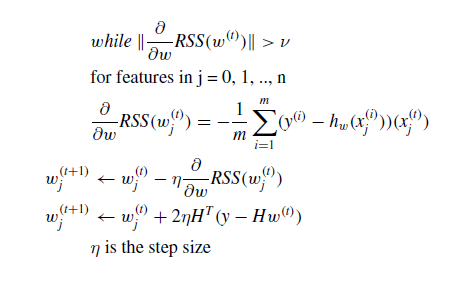

In order to minimize the the cost, **tolerance** is calculated as follow:

$||\frac{\partial}{\partial w}RSS(w^{(t)})|| = \sqrt{\frac{\partial}{\partial w}RSS(w_0^{(t)})^2 + \frac{\partial}{\partial w}RSS(w_1^{(t)})^2 + ... + \frac{\partial}{\partial w}RSS(w_m^{(t)})^2}$

### d) Writing the Batch Gradient Descent Application

In order to write the the Batch Gradient Descent application, four functions need to be defined:

- **data_matrix** - receives the features and scales them before returning the matrix and output; this will help further in the gradient descent algorithm (ensure faster convergence)

```r
data_matrix <- function(data, features, output){
  scaled_feature_matrix <- data.frame(scale(data[features]), row.names=NULL)
  length <- nrow(data)
  scaled_features <- as.matrix(cbind('Intercept' = rep(1, length),
                               scaled_feature_matrix[, features]))
  output <- as.matrix(scale(data[output]))
  return(list(scaled_features, output))
}
```

- **predict_output** - receives the features and weights (for each feature) and returns the predictions.

```r
predict_output = function(feature_matrix, weights) {
  predictions = (as.matrix(feature_matrix)) %*% weights
  return(predictions)
}
```

- **featureDerivative** - calculates the RSS gradient at each feature

```r
featureDerivative = function(errors, features) {
  derivative = -1/nrow(features) * (t(features) %*% errors)
  return(derivative)
}
```

- **regression_gradient_descent** - the function which executes the algorithm described above (c); it returns the computed weights (for each feature) and the number of steps it took to converge.

```r
regression_gradient_descent = function(feature_matrix, output,
  initial_weights, step_size, tolerance) {
  converged = FALSE
  weights = initial_weights
  i = 0
  while (!converged) {
    predictions = predict_output(feature_matrix, weights)
    errors = predictions - output
    gradient = featureDerivative(errors, feature_matrix)
    gradient_norm = sqrt(sum(gradient^2))
    weights = weights + step_size * gradient
    if (gradient_norm < tolerance) {
    converged = TRUE
    }
    i = i + 1
  }
  return(list(weights = weights, Iters = i))
}
```

### EXAMPLE

“kc_house_data.csv” file will be used - available at kaggle. It contains data about the houses sold in King County, Portland, Oregon from May 2014 to May 2015.

**STEPS** to use gradient descent algorithm:

- select as dependent variable the *price* and as predictor the *sqft_living* and *bedrooms* values;

```r
file_path = "./"
kc_house_data <- read.csv(paste(file_path, "kc_house_data.csv",
sep = ""))
house_data <- kc_house_data[, c("price", "bedrooms", "sqft_living")]
```

- split the data into **train data** and **test data**;

```r
library(caret)
set.seed(22)
inTrain <- createDataPartition(house_data$price, p = 0.5, list = F)
house_train_data = house_data[inTrain,]
house_test_data = house_data[-inTrain,]
```

- define the **features** and the **output**;

```r
my_features <- c("bedrooms", "sqft_living")
my_output <- "price"
```

- construct **feature matrix** and **output matrix**; initialize the weights, step size and tolerance;

```r
feature_matrix = data_matrix(house_train_data, my_features, my_output)[[1]]
output_matrix = data_matrix(house_train_data, my_features, my_output)[[2]]
initial_weights = c(0, 0, 0)
step_size = 0.01
tolerance = 1e-5
```

- run the gradient descent algorithm and find the feature weights;

```r
weights = regression_gradient_descent(feature_matrix,
                                      output_matrix,
                                      initial_weights,
                                      step_size,
                                      tolerance)
weights
```

```
## $weights
##                     price
## Intercept    1.600084e-16
## bedrooms    -1.386515e-01
## sqft_living  7.841367e-01
##
## $Iters
## [1] 2296
```

- check with **OLS regressions** in R

```r
scaled_house_data <- data.frame(scale(house_train_data))
lm(price ~ ., data = scaled_house_data)$coef
```

```
##   (Intercept)      bedrooms   sqft_living
##  9.399926e-17 -1.386672e-01  7.841524e-01
```

**Gradient descent** can also be used from R **package, gettingtothebottom** by calling **gdescent function**.  
gdescent(f, grad_f, X,y, alpha, iter, tol, …):

- f: objective function
- grad_f: gradient of the objective function
- X: feature matrix
- y: response vector
- alpha: step size alpha
- iter: number of iterations
- tol: tolerance

```r
library(gettingtothebottom)
X <- as.matrix(feature_matrix[, -1])
y <- as.vector(output_matrix)

# initialize the weights
b <- c(0, 0, 0)

# define the objective function
f <- function(X, y, b) {
  (1/2) * norm(y - X %*% b, "F")^2
}

# Calculate gradient of the objective function
grad_f <- function(X, y, b) {
  t(X) %*% (X %*% b - y)
}
```

```r
gradient_descent <- gdescent(f,
                             grad_f,
                             X, y,
                             alpha = 10e-5,
                             iter = 10e7,
                             tol = 1e-5)
```

```
## Minimum function value:
##  2626.583
##
## Intercept:
##  1.653344e-16
##
## Coefficient(s):
##  -0.1386672 0.7841524
```

**Conclusion!** Same results obtained in both cases (implementing the functions vs using function from R package)  
**Important!** When choosing the tolerance and step size values it is better to start from:

- higher step size -> may lead to non-convergence
- low tolerance -> might take a long time to converge

### e) Writing the Stochastic Gradient Descent Application

Stochastic Gradient Descent is used when dealing with large size data (e.g. m = 1e20). Unlike the batch gradient descent which goes through all the cases, Stochastic Gradient Descent selects randomly from the data set and starts modifying the parameters right away. The process is repeated until there are no more entries in the data set.

The procedure is repeated by the number of iterations defined.

```r
sgd<-function(x, y, betas, iters, lambda)
{
  beta<-as.matrix(cbind(rep(betas[1], iters),
                  rep(betas[2], iters),
                  rep(betas[3],iters))
                 )
  for (i in 2:iters)
  {
    m <- nrow(x)
    sample_num <- sample.int(m, 1)
    row_x <- x[sample_num,]
    row_y <- y[sample_num]
    beta[i, 1] <- beta[i-1, 1] - (lambda*(beta[i-1, 1] +
                                  beta[i-1, 2]*row_x[[1]] +
                                  beta[i-1, 3]*row_x[[2]] -
                                  row_y)
                                 )
    beta[i, 2] <- beta[i-1, 2] - (lambda*(beta[i-1, 1] +
                                  beta[i-1, 2]*row_x[[1]] +
                                  beta[i-1,3]*row_x[[2]] -
                                  row_y)*row_x[[1]]
                                 )
    beta[i, 3] <- beta[i-1,3] - lambda*(beta[i-1, 1] +
                                        beta[i-1, 2]*row_x[[1]] +
                                        beta[i-1,3]*row_x[[2]] -
                                        row_y)*row_x[[2]]
  }
  return(beta);
}
```

```r
betas = c(0, 0, 0)
iters = 3000
lambda = 0.0001
weights = sgd(feature_matrix[, -1],
              output_matrix,
              betas,
              iters = iters,
              lambda = lambda)
weights[1:10,]
```

```
##                [,1]         [,2]         [,3]
##  [1,]  0.000000e+00 0.0000000000 0.000000e+00
##  [2,] -8.420339e-05 0.0001226882 7.720778e-05
##  [3,] -6.094916e-05 0.0001625160 1.263826e-04
##  [4,]  4.736029e-05 0.0002335805 1.041208e-04
##  [5,]  9.874577e-06 0.0002089852 1.011589e-04
##  [6,]  7.464741e-06 0.0002048578 9.812012e-05
##  [7,]  1.880802e-04 0.0003233642 5.275016e-04
##  [8,]  9.210612e-05 0.0003617980 6.333585e-04
##  [9,]  1.329046e-04 0.0003454598 6.562287e-04
## [10,]  6.041501e-05 0.0003744890 7.139690e-04
```

## **5. Linear Regression Assumptions**

Linear regression assumptions:

### a) **Linear Relationship**

between the response and the predictors; the values of the residuals and the predicted can be plotted to best see the relationship. Non-linearity can be detected if there is any particular pattern in the plot, but is not always the case (see **5.2** where the plot between fitted values and the residuals of the polynomial regression model does not show any pattern)

Non-linearity **example** for the regression model:

$y = w_0 + w_1x+w_2x^2+...+w_5x^5$

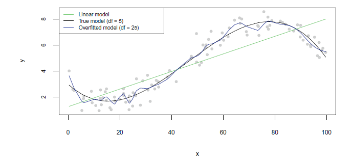

**5.1. Non-linear Relationship**

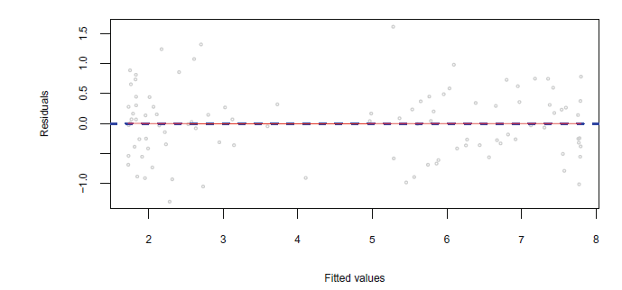

**5.2. Residuals vs fitted/predicted values**

### b) **Residuals have zero mean**

```r
# mean(fit$residuals)
```

[1] -1.404042e-19

### c) **No autocorrelation of residuals:**

The correlation occurs usually when dealing with *time series* data. “**The null hypothesis autocorrelation of the residuals is 0**” can be tested as below.

```r
# (lmtest::dwtest(fit))$p.value
```

[1] 0.3654994

If p-value is grater than 0.05, then the null hypothesis autocorrelation of the residuals is 0 is accepted.

### d) **Homoscedasticity of residuals:**

**Homoscedasticity** = “equal variance”; it happens when the error is the same for all the values of the independent variables.  
Example of Homoscedasticity in image 5.2.  
**Heteroscedasticity** = violation of Homoscedasticity; it happens when the error is different across the values of the independent variable.